# Data624 Project 2

Group 4

2021-07-06

Group Members

- Subhalaxmi Rout
- Kenan Sooklall
- Devin Teran
- Christian Thieme
- Leo Yi

## Introduction

We have been given a dataset from a beverage manufacturing company that consists of 2,571 rows of data and 33 columns. The dataset contains information on different beverages and their chemical composition. The goal of this analysis is to use the 32 predictive features to predict the *Potential for hydrogen* (pH), which is a measure of the acidity/alkalinity of the beverage. pH is an important KPI.

We’ll begin by reading in the dataset and looking at each column’s data type:

```
## Rows: 2,571
## Columns: 33
## $ `brand code`        <chr> "B", "A", "B", "A", "A", "A", "A", "B", "B", "B...
## $ `carb volume`       <dbl> 5.340000, 5.426667, 5.286667, 5.440000, 5.48666...
## $ `fill ounces`       <dbl> 23.96667, 24.00667, 24.06000, 24.00667, 24.3133...
## $ `pc volume`         <dbl> 0.2633333, 0.2386667, 0.2633333, 0.2933333, 0.1...
## $ `carb pressure`     <dbl> 68.2, 68.4, 70.8, 63.0, 67.2, 66.6, 64.2, 67.6,...
## $ `carb temp`         <dbl> 141.2, 139.6, 144.8, 132.6, 136.8, 138.4, 136.8...
## $ psc                 <dbl> 0.104, 0.124, 0.090, NA, 0.026, 0.090, 0.128, 0...
## $ `psc fill`          <dbl> 0.26, 0.22, 0.34, 0.42, 0.16, 0.24, 0.40, 0.34,...
## $ `psc co2`           <dbl> 0.04, 0.04, 0.16, 0.04, 0.12, 0.04, 0.04, 0.04,...
## $ `mnf flow`          <dbl> -100, -100, -100, -100, -100, -100, -100, -100,...
## $ `carb pressure1`    <dbl> 118.8, 121.6, 120.2, 115.2, 118.4, 119.6, 122.2...
## $ `fill pressure`     <dbl> 46.0, 46.0, 46.0, 46.4, 45.8, 45.6, 51.8, 46.8,...
## $ `hyd pressure1`     <dbl> 0, 0, 0, 0, 0, 0, 0, 0, 0, 0, 0, 0, 0, 0, 0, 0,...
```

[output cut: 20 more lines]

We see that all columns with the exception of `brand` are doubles and continuous. Excluding the response variable, this means that we have 1 categorical variable and 31 continuous variables to work with.

## Exploratory Data Analysis

In the output above, we can see that there are missing values (NAs). Let’s see how pervasive this issue is within our dataset:

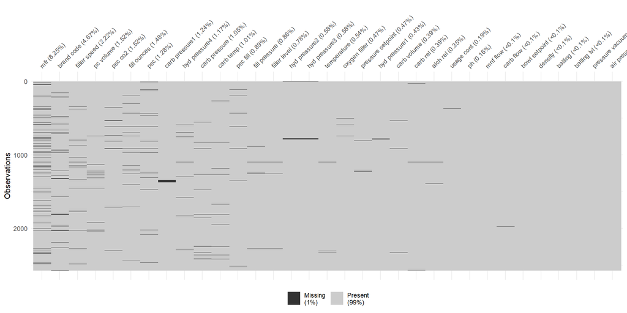

In total, only about 1% of our data is missing. We can see that most of the columns are barely missing any data. However, `mfr` and `brand code` are missing 8.25% and 4.67% of their data, respectively. Now that we understand that our missing values are not a pervasive issue, we’ll continue with our analysis.

#### Distribution of Response Variable: pH

Let’s get an understanding of the distribution of our response variable:

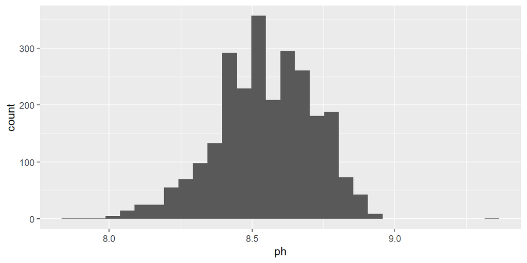

[figure not shown]